# Chapter 7: Exploratory Data Analysis

## 7.5.1.1 Exercises

1. Use what you’ve learned to improve the visualisation of the departure times of cancelled vs. non-cancelled flights.

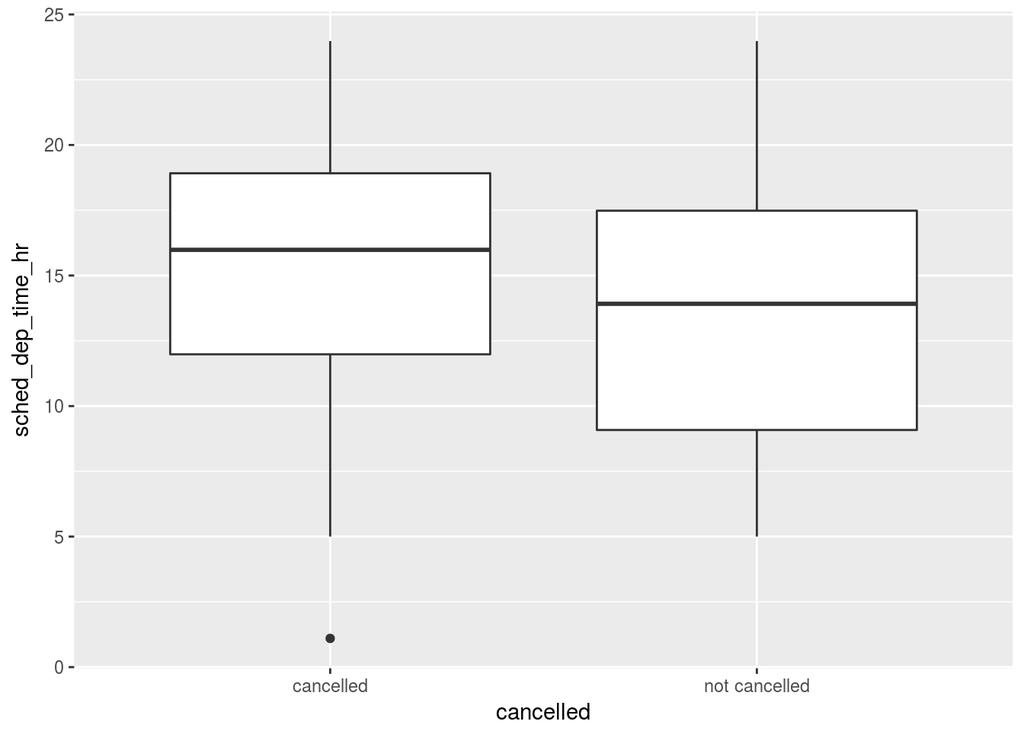

```r
nycflights13::flights %>%
  mutate(cancelled = if_else(is.na(dep_delay), "cancelled", "not cancelled")) %>%
  mutate(sched_dep_time_hr = hour + minute / 60) %>%
  ggplot() +
    geom_boxplot(mapping = aes(x = cancelled, y = sched_dep_time_hr))
```

2. What variable in the diamonds dataset is most important for predicting the price of a diamond? How is that variable correlated with cut? Why does the combination of those two relationships lead to lower quality diamonds being more expensive?
3. Install the ggstance package, and create a horizontal boxplot. How does this compare to using coord_flip()?

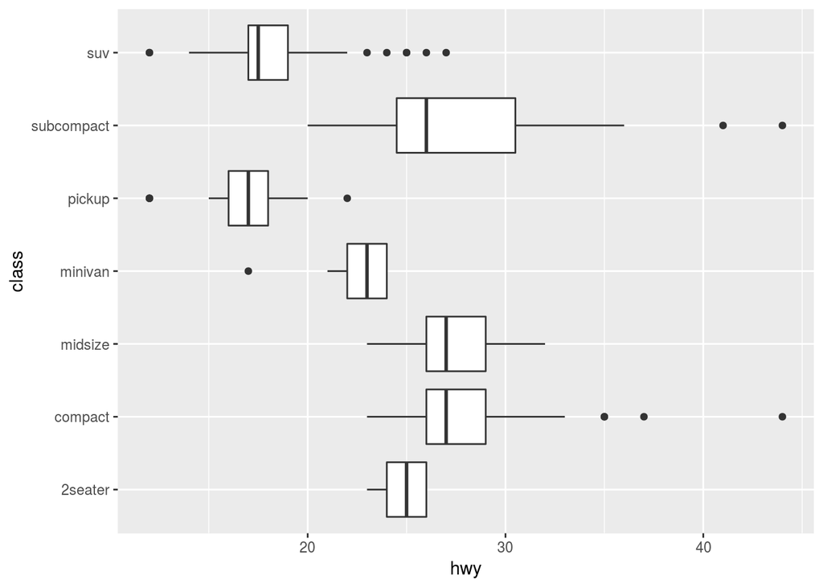

```r
ggplot(mpg) +
  geom_boxplot(mapping = aes(x = class, y = hwy)) +
  coord_flip()
```

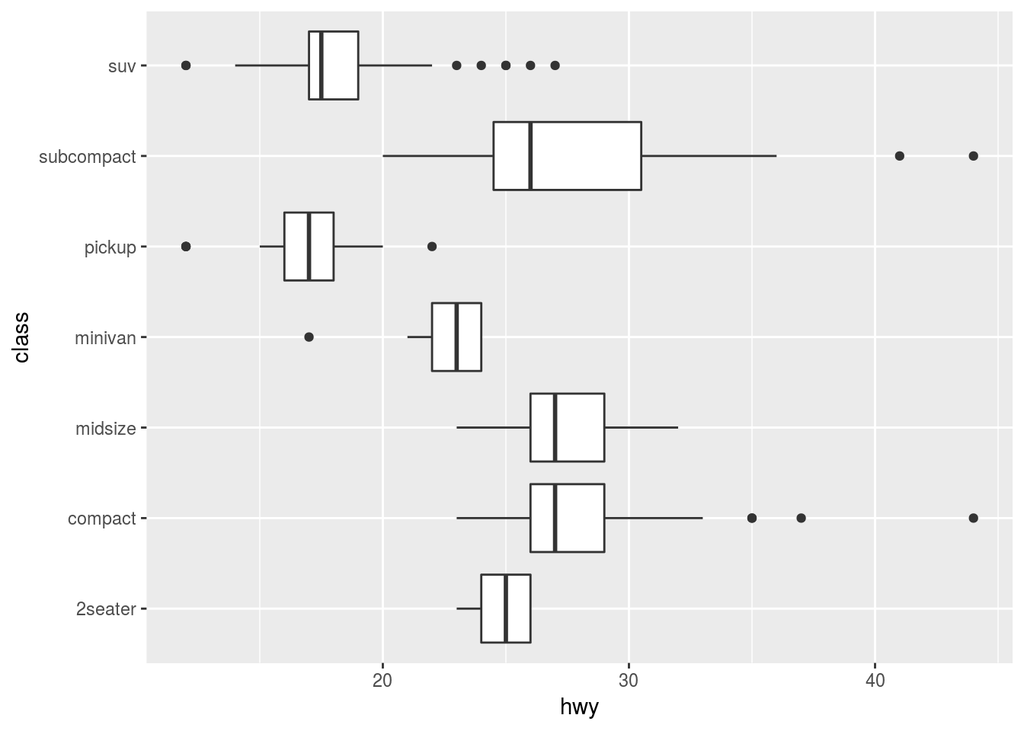

```r
ggplot(mpg) +
  geom_boxploth(mapping = aes(x = hwy, y = class))
```

4. One problem with boxplots is that they were developed in an era of much smaller datasets and tend to display a prohibitively large number of “outlying values”. One approach to remedy this problem is the letter value plot. Install the lvplot package, and try using geom_lv() to display the distribution of price vs cut. What do you learn? How do you interpret the plots?

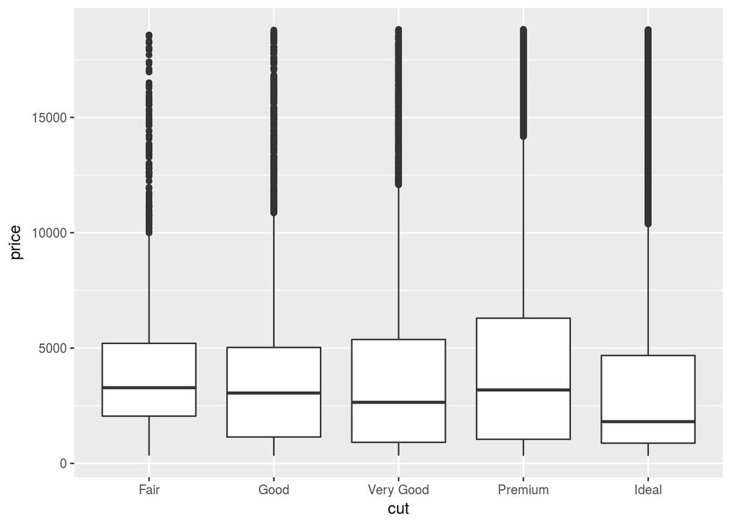

```r
ggplot(data = diamonds) +
  geom_boxplot(mapping = aes(x = cut, y = price))
```

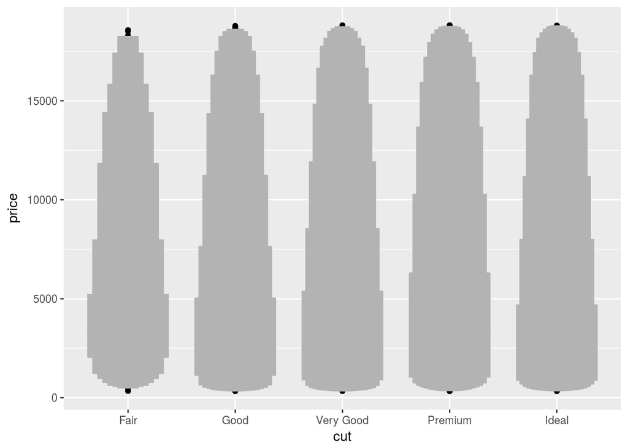

```r
ggplot(data = diamonds) +
  geom_lv(mapping = aes(x = cut, y = price))
```

5. Compare and contrast geom_violin() with a facetted geom_histogram(), or a coloured geom_freqpoly(). What are the pros and cons of each method?

Violin

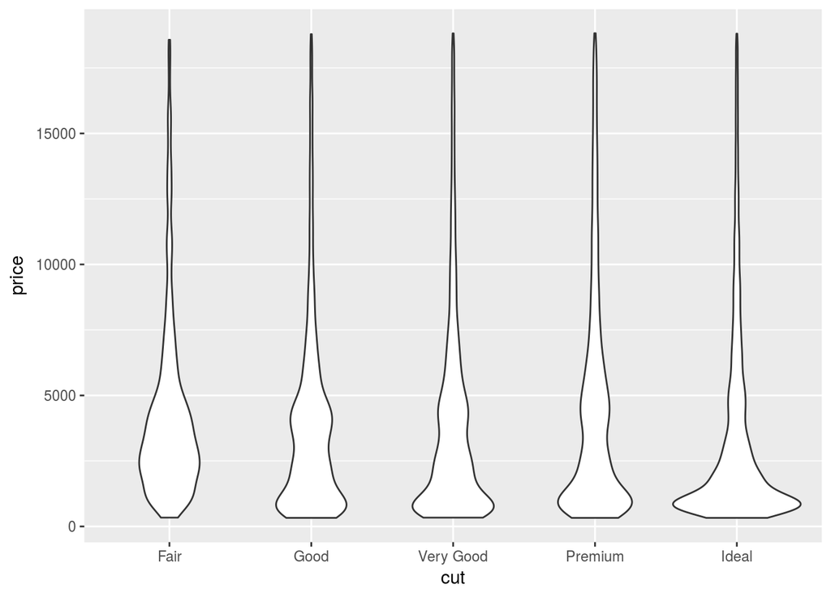

```r
ggplot(data = diamonds) +
  geom_violin(mapping = aes(x = cut, y = price))
```

Facetted histogram

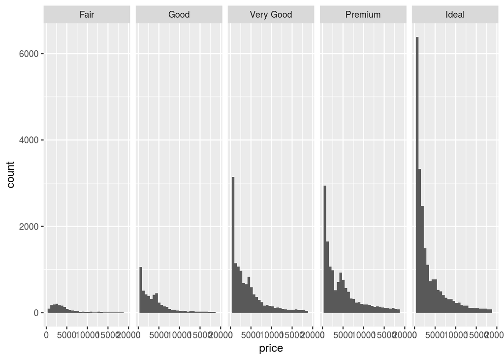

```r
ggplot(data = diamonds) +
  geom_histogram(mapping = aes(x = price)) +
  facet_wrap(~ cut, nrow = 1)
```

Colured frequency

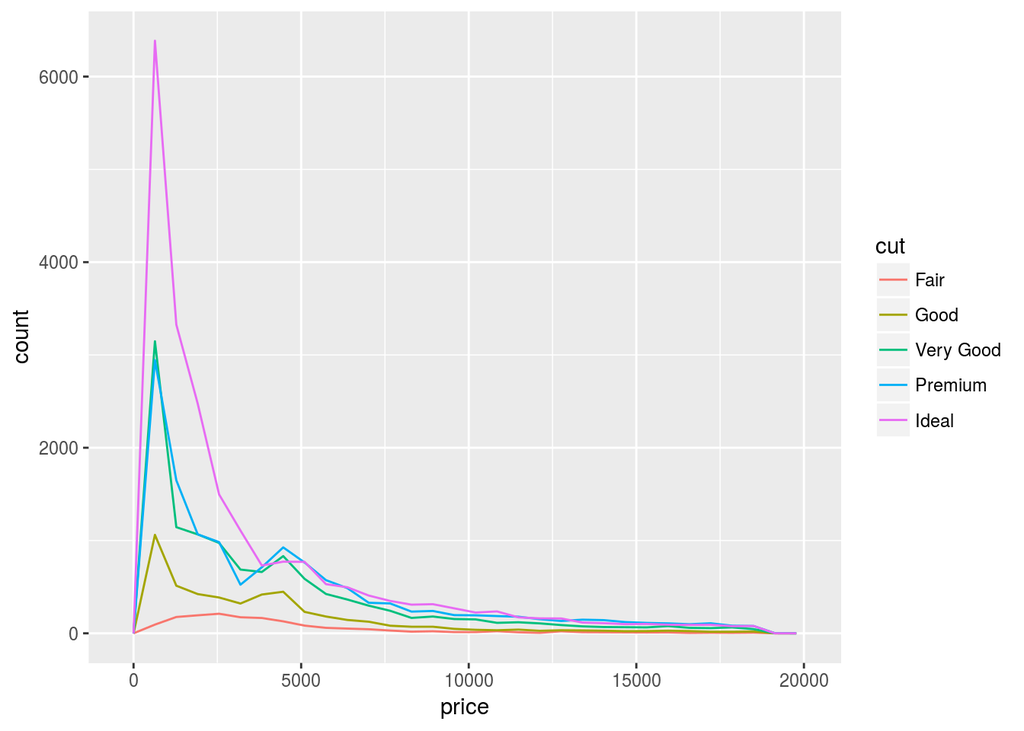

```r
ggplot(data = diamonds) +
  geom_freqpoly(mapping = aes(x = price, colour = cut))
```

6. If you have a small dataset, it’s sometimes useful to use `geom_jitter()` to see the relationship between a continuous and categorical variable. The `ggbeeswarm` package provides a number of methods similar to `geom_jitter()`. List them and briefly describe what each one does.

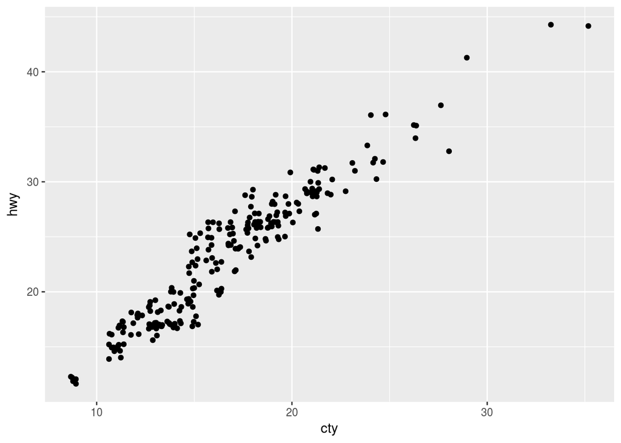

```r
ggplot(data = mpg) +
  geom_jitter(mapping = aes(x = cty, y = hwy))
```

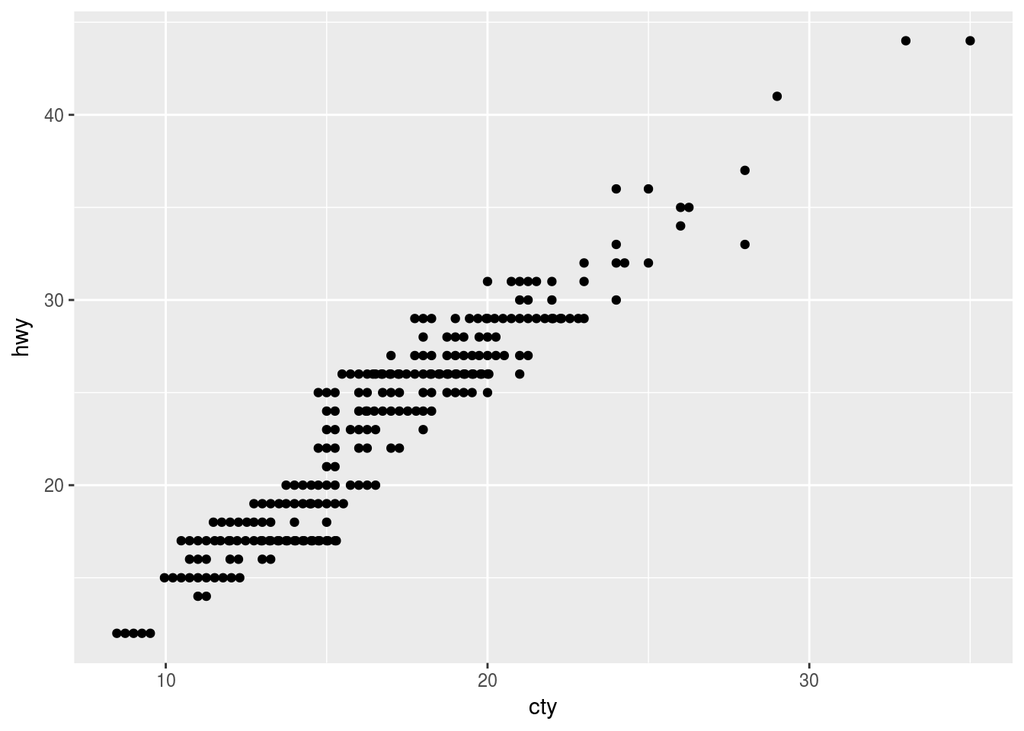

```r
ggplot(data = mpg) +
  geom_beeswarm(mapping = aes(x = cty,y = hwy))
```

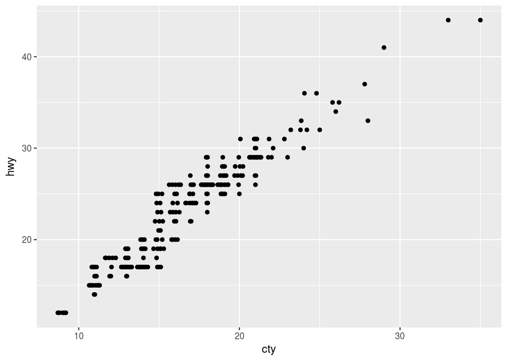

```r
ggplot(data = mpg) +
  geom_quasirandom(mapping = aes(x = cty,y = hwy))
```

Two categorical variables

Counts for each combination

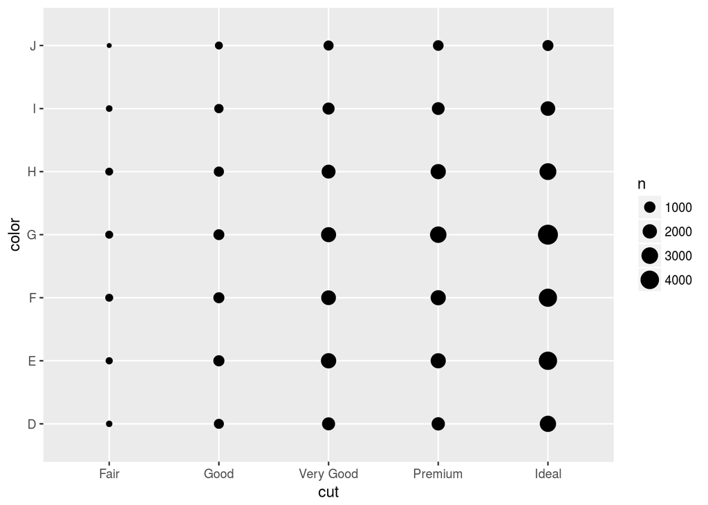

```r
ggplot(data = diamonds) +
  geom_count(mapping = aes(x = cut, y = color))
```

```r
diamonds %>%
  count(color, cut)
```

```
## Source: local data frame [35 x 3]
## Groups: color [?]
##
##    color       cut     n
##    <ord>     <ord> <int>
## 1      D      Fair   163
## 2      D      Good   662
## 3      D Very Good  1513
## 4      D   Premium  1603
## 5      D     Ideal  2834
## 6      E      Fair   224
## 7      E      Good   933
## 8      E Very Good  2400
## 9      E   Premium  2337
## 10     E     Ideal  3903
## # ... with 25 more rows
```

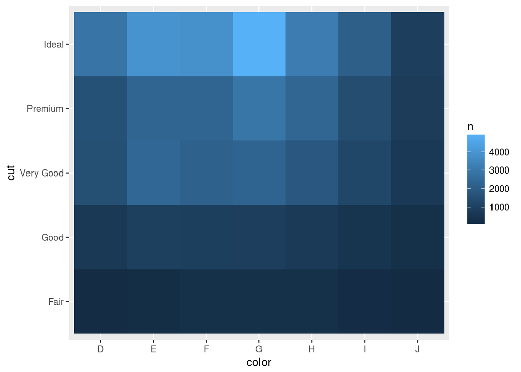

```r
diamonds %>%
  count(color, cut) %>%
  ggplot(mapping = aes(x = color, y = cut)) +
    geom_tile(mapping = aes(fill = n))
```